# MLB mock report

```
Report date: 2022-10-11
League name: American League
```

## League standings

Time series evolution of number of wins and win-total ratio:

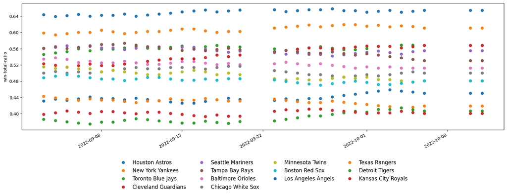

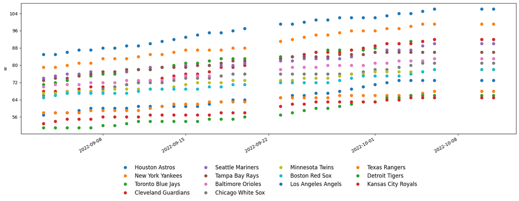

## Batting summary

Time series evolution of home runs and obp:

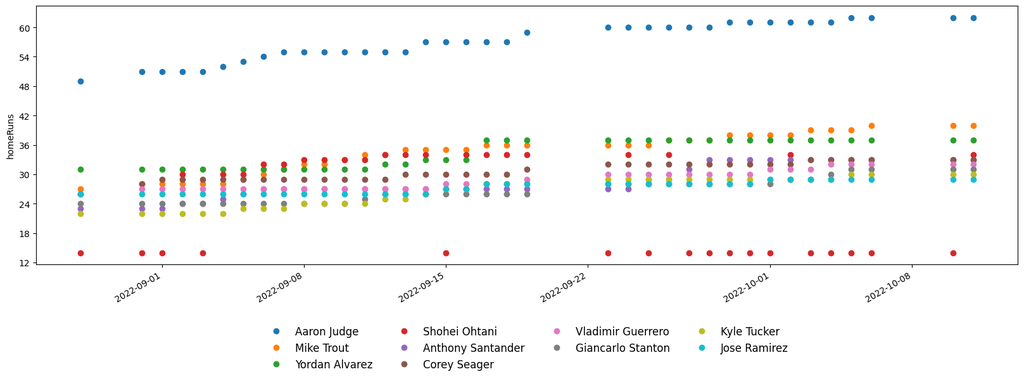

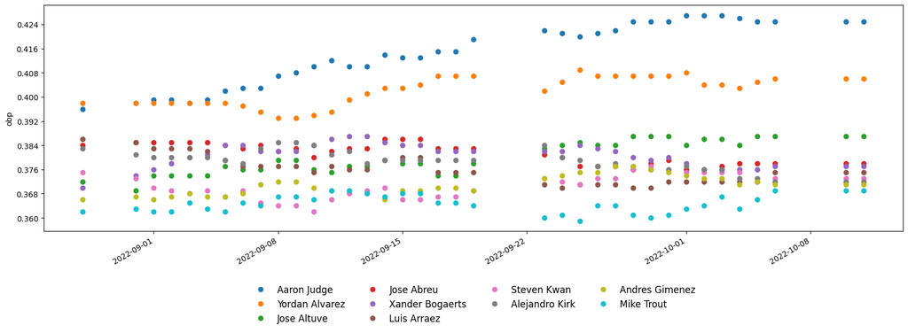

### Runs batted in (RBI)

Who is really 🔥💥 ?

|  | playername | rbiperplateAppearance |
| --- | --- | --- |
| 592450 | Aaron Judge | 0.188220 |
| 608070 | Jose Ramirez | 0.183940 |
| 643376 | Danny Jansen | 0.177420 |
| 663656 | Kyle Tucker | 0.175700 |
| 670541 | Yordan Alvarez | 0.172910 |
| 519317 | Giancarlo Stanton | 0.172570 |
| 596115 | Trevor Story | 0.166670 |
| 671221 | Drew Waters | 0.165140 |
| 650391 | Eloy Jimenez | 0.165140 |
| 521692 | Salvador Perez | 0.160680 |

And who is not 🧊🐢 ?

|  | playername | rbiperplateAppearance |
| --- | --- | --- |
| 681146 | Jonah Bride | 0.032090 |
| 668731 | Akil Baddoo | 0.040000 |
| 670032 | Nicky Lopez | 0.041670 |
| 669352 | Bubba Thompson | 0.049720 |
| 605353 | Vimael Machin | 0.051380 |
| 571466 | Tucker Barnhart | 0.051950 |
| 664702 | Myles Straw | 0.053690 |
| 676632 | Bligh Madris | 0.056910 |
| 669397 | Nick Allen | 0.058280 |
| 624512 | Reese McGuire | 0.060240 |

Who to watch? Biggest improvement from last week:

|  | playername | rbiperplateAppearancedifference |
| --- | --- | --- |
| 543877 | Christian Vazquez | 0.016400 |
| 664238 | Dylan Moore | 0.010450 |
| 462101 | Elvis Andrus | 0.009230 |
| 571745 | Mitch Haniger | 0.007400 |
| 596142 | Gary Sanchez | 0.007190 |
| 502110 | J.D. Martinez | 0.005720 |
| 679529 | Spencer Torkelson | 0.005370 |
| 593428 | Xander Bogaerts | 0.005290 |
| 682985 | Riley Greene | 0.005120 |
| 518586 | Charlie Culberson | 0.005110 |

### Homeruns (HRs)

Who is really 🔥💥 ?

|  | playername | homeRunsperplateAppearance |
| --- | --- | --- |
| 592450 | Aaron Judge | 0.089080 |
| 545361 | Mike Trout | 0.080160 |
| 621439 | Byron Buxton | 0.073300 |
| 519317 | Giancarlo Stanton | 0.068580 |
| 670541 | Yordan Alvarez | 0.065950 |
| 663728 | Cal Raleigh | 0.065060 |
| 643376 | Danny Jansen | 0.060480 |
| 519203 | Anthony Rizzo | 0.058390 |
| 681481 | Kerry Carpenter | 0.053100 |
| 670623 | Isaac Paredes | 0.052490 |

And who is not 🧊🐢 ?

|  | playername | homeRunsperplateAppearance |
| --- | --- | --- |
| 624512 | Reese McGuire | 0.000000 |
| 670032 | Nicky Lopez | 0.000000 |
| 664702 | Myles Straw | 0.000000 |
| 444482 | David Peralta | 0.000000 |
| 571466 | Tucker Barnhart | 0.003250 |
| 605353 | Vimael Machin | 0.003950 |
| 624428 | Adam Frazier | 0.004980 |
| 681146 | Jonah Bride | 0.005350 |
| 669352 | Bubba Thompson | 0.005520 |
| 665482 | Gilberto Celestino | 0.005760 |

Who to watch? Biggest improvement from last week:

|  | playername | homeRunsperplateAppearancedifference |
| --- | --- | --- |
| 660271 | Shohei Ohtani | 0.029740 |
| 543877 | Christian Vazquez | 0.009260 |
| 518586 | Charlie Culberson | 0.007800 |
| 571745 | Mitch Haniger | 0.006720 |
| 660644 | Vidal Brujan | 0.005860 |
| 519390 | Stephen Vogt | 0.004560 |
| 679529 | Spencer Torkelson | 0.004460 |
| 665828 | Oswaldo Cabrera | 0.003640 |
| 664728 | Kyle Isbel | 0.003230 |
| 462101 | Elvis Andrus | 0.003160 |

### Strike-outs

Remember, unlike runs batted in and home-runs, strike-outs are bad! You cannot score runs if you do not put the ball in play!

Who is really 🔥💥 ?

|  | playername | strikeOutsperplateAppearance |
| --- | --- | --- |
| 664058 | David Fletcher | 0.070175 |
| 650333 | Luis Arraez | 0.071310 |
| 680757 | Steven Kwan | 0.094044 |
| 677551 | Wander Franco | 0.095930 |
| 672386 | Alejandro Kirk | 0.107209 |
| 650490 | Yandy Diaz | 0.107527 |
| 686469 | Vinnie Pasquantino | 0.114094 |
| 608324 | Alex Bregman | 0.117378 |
| 608070 | Jose Ramirez | 0.119708 |
| 624428 | Adam Frazier | 0.121262 |

And who is not 🧊🐢 ?

|  | playername | strikeOutsperplateAppearance |
| --- | --- | --- |
| 660650 | Dermis Garcia | 0.440000 |
| 673962 | Josh Jung | 0.382353 |
| 666176 | Jo Adell | 0.375439 |
| 671221 | Drew Waters | 0.366972 |
| 668472 | Nick Pratto | 0.362637 |
| 663853 | Romy Gonzalez | 0.357798 |
| 669127 | Shea Langeliers | 0.346405 |
| 676694 | Jake Meyers | 0.337500 |
| 642350 | Jose Siri | 0.337079 |
| 672284 | Jarred Kelenic | 0.337017 |

Who to watch? Biggest improvement from last week:

|  | playername | strikeOutsperplateAppearancedifference |
| --- | --- | --- |
| 660271 | Shohei Ohtani | -0.082460 |
| 681987 | Nate Eaton | -0.014970 |
| 669127 | Shea Langeliers | -0.014140 |
| 669352 | Bubba Thompson | -0.010380 |
| 672284 | Jarred Kelenic | -0.008220 |
| 462101 | Elvis Andrus | -0.007770 |
| 665828 | Oswaldo Cabrera | -0.006840 |
| 660644 | Vidal Brujan | -0.005780 |
| 642350 | Jose Siri | -0.005780 |
| 571745 | Mitch Haniger | -0.005750 |

## Batting stats charts

A short explanation of the meaning of each chart, in order. If not explicitly mentioned, the variables are normalized by the number of plate appearances:

1. y-var: Normalized ops (obp + slugging), x-var: StrikeOutsPerPlateAppearance - In theory, these variables should be slightly negatively (i.e, inversely) correlated. Roughly speaking, aggressive batters, which hit for power often, are more likely to strike out. This chart is relevant to determine outliers. Excellent sluggers will appear above the rest of the players, while maintaining a low strikeOutperPlateAppearance.
2. y-var: Base on Balls (i.e, walks), x-var: StrikeOuts - In theory, these variables should be negatively (i.e, inversely) correlated. Roughly speaking, aggressive batters which attack the ball thrown by the pitcher more often should walk fewer times because they are more likely to attack balls outside the strikezone, for which they could earn a walk.
3. y-var: Normalized obp, x-var: Difference between StrikeOuts and BaseOnBalls - In theory, these variables should be inversely correlated, because to obtain a large on base percentage (obp), the batter must avoid getting striked out. This chart is particularly useful to determine players which are extremely good at hitting for contact - those with an ops above league average and a negative difference between StrikeOuts and Base On Balls - i.e, the top left corner of the chart). These might not score a lot of homeRuns, but they get on base very often and allow their team the possibility to score runs.
4. y-var: homeRuns, x-var: StrikeOuts - In theory, these variables should be positively correlated. Following 1., aggressive batters try to generate powerful contact with the ball more often. They will receive more homeRuns at the expense of more StrikeOuts. Elite players should be placed in the top half of the chart, towards the left.
5. y-var: totalBases , x-var: hits, both as a league z-score - These variables are proportional - to score a single, double or triple, the batter must hit the ball. On average, the batter will receive one base per hit. This chart is relevant to determine outliers. That is, Aaron Judge is an absolute freak!

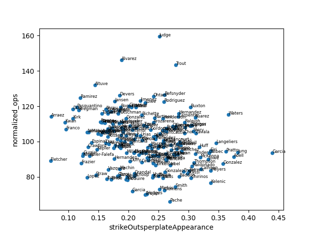

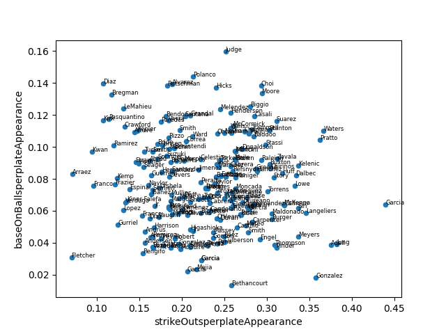

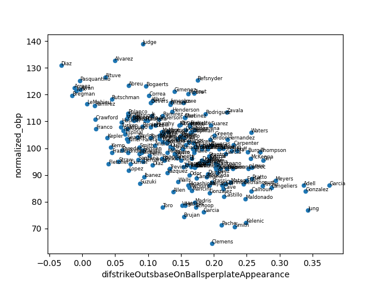

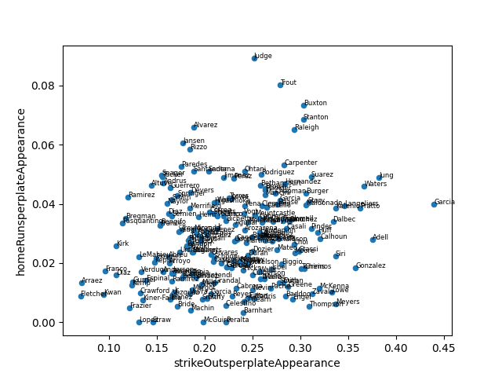

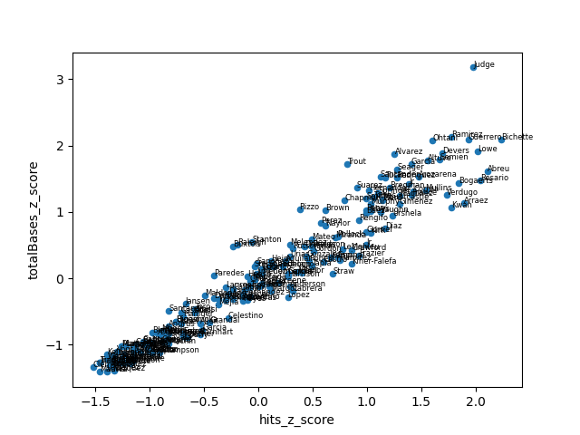